# هوش مصنوعی

### پروژه ۴

### سنا ساری نوایی - 810199435

```python
import pandas as pd
import matplotlib.pyplot as plt
import seaborn as sns
import numpy as np
from sklearn.model_selection import train_test_split
from sklearn.neighbors import KNeighborsClassifier
from sklearn.tree import DecisionTreeClassifier
from sklearn.linear_model import LogisticRegression
from sklearn.model_selection import GridSearchCV
from sklearn import metrics
from sklearn.ensemble import RandomForestClassifier
```

# هدف پروژه

هدف از این پروژه، آشنایی با روش های یادگیری ماشین و تخمین داشتن دیابت بر اساس داده جمع آوری شده میباشد. که شامل 4 فاز میباشد.

# بررسی مجموعه داده

سوال 1:

()describe اطلاعاتی از قبیل تعداد، میانگین، انحراف معیار، مینیموم، ماکسیمم، چارک اول، دوم و سوم در اختیار ما قرار میدهد و از این مقادیر میتوانیم اطلاعاتی راجع به دیتای خودمان به دست بیاوریم. به عنوان مثال ستون هایی که انحراف معیار زیادی دارند به این معناست که در آن ستون داده هایی قرار دارد که اختلاف زیادی با بقیه دارند. یا از طریق مینیموم و ماکسیمم میتوانیم حدود بازه برای هر ستون را بفهمیم.

()info اطلاعاتی درمورد کل ستون ها در اختیار ما قرار میدهد. به عنوان مثال، تعداد ستون ها و همچنین type هرکدام را نمایش میدهد. از طرف دیگر، میزان حافظه اشغال شده را نیز به ما میدهد. به عنوان مثال به ما نشان میدهد که 768 داده و 9 ستون داریم و همچنین تایپ outcome مانند بقیه داده ها نیست و int64 است.

```python
data = pd.read_csv("diabetes.csv")
data
```

|  | Pregnancies | Glucose | BloodPressure | SkinThickness | Insulin | BMI | DiabetesPedigreeFunction | Age | Outcome |
| --- | --- | --- | --- | --- | --- | --- | --- | --- | --- |
| 0 | 6.0 | 148.0 | 72.0 | 35.0 | 0.0 | 33.6 | 0.627 | 50.0 | 1 |
| 1 | 1.0 | 85.0 | 66.0 | 29.0 | 0.0 | 26.6 | 0.351 | 31.0 | 0 |
| 2 | NaN | 183.0 | 64.0 | 0.0 | 0.0 | 23.3 | 0.672 | 32.0 | 1 |
| 3 | 1.0 | 89.0 | 66.0 | 23.0 | 94.0 | 28.1 | 0.167 | 21.0 | 0 |
| 4 | NaN | 137.0 | 40.0 | 35.0 | 168.0 | NaN | NaN | 33.0 | 1 |
| ... | ... | ... | ... | ... | ... | ... | ... | ... | ... |
| 763 | 10.0 | 101.0 | 76.0 | 48.0 | 180.0 | 32.9 | NaN | 63.0 | 0 |
| 764 | 2.0 | 122.0 | 70.0 | NaN | 0.0 | 36.8 | 0.340 | NaN | 0 |
| 765 | 5.0 | NaN | 72.0 | 23.0 | 112.0 | 26.2 | 0.245 | 30.0 | 0 |
| 766 | 1.0 | 126.0 | 60.0 | NaN | 0.0 | 30.1 | 0.349 | NaN | 1 |
| 767 | NaN | 93.0 | NaN | 31.0 | NaN | 30.4 | 0.315 | 23.0 | 0 |

768 rows × 9 columns

```python
data.describe()
```

|  | Pregnancies | Glucose | BloodPressure | SkinThickness | Insulin | BMI | DiabetesPedigreeFunction | Age | Outcome |
| --- | --- | --- | --- | --- | --- | --- | --- | --- | --- |
| count | 635.000000 | 654.000000 | 680.000000 | 624.000000 | 680.000000 | 684.000000 | 590.000000 | 655.000000 | 768.000000 |
| mean | 3.700787 | 113.422018 | 68.786765 | 20.386218 | 80.123529 | 32.083626 | 0.466676 | 33.157252 | 0.348958 |
| std | 3.518126 | 202.816831 | 19.724841 | 15.987049 | 115.681140 | 7.800741 | 0.322408 | 13.829831 | 0.476951 |
| min | -22.000000 | -5000.000000 | -2.000000 | 0.000000 | 0.000000 | 0.000000 | 0.078000 | -150.000000 | 0.000000 |
| 25% | 1.000000 | 99.000000 | 62.000000 | 0.000000 | 0.000000 | 27.375000 | 0.243250 | 24.000000 | 0.000000 |
| 50% | 3.000000 | 117.000000 | 72.000000 | 23.000000 | 34.000000 | 32.300000 | 0.368000 | 29.000000 | 0.000000 |
| 75% | 6.000000 | 140.750000 | 80.000000 | 32.000000 | 129.250000 | 36.600000 | 0.611500 | 41.000000 | 1.000000 |
| max | 17.000000 | 199.000000 | 122.000000 | 99.000000 | 846.000000 | 67.100000 | 2.329000 | 81.000000 | 1.000000 |

```python
data.info()
```

```
<class 'pandas.core.frame.DataFrame'>
RangeIndex: 768 entries, 0 to 767
Data columns (total 9 columns):
 #   Column                    Non-Null Count  Dtype
---  ------                    --------------  -----
 0   Pregnancies               635 non-null    float64
 1   Glucose                   654 non-null    float64
 2   BloodPressure             680 non-null    float64
 3   SkinThickness             624 non-null    float64
 4   Insulin                   680 non-null    float64
 5   BMI                       684 non-null    float64
 6   DiabetesPedigreeFunction  590 non-null    float64
 7   Age                       655 non-null    float64
 8   Outcome                   768 non-null    int64
dtypes: float64(8), int64(1)
memory usage: 54.1 KB
```

سوال 2:

با استفاده از تابع ()isnull.()sum ابتدا مقدار داده های از دست رفته را بدست می‌آوریم و سپس با تقسیم کردن این مقدار بر اندازه دیتا، نسبت داده های از دست رفته در هر گروه مشخص میشود.

```python
print("Number of missing values in each column in data:")
data.isnull().sum()
```

```
Number of missing values in each column in data:
```

```
Pregnancies                 133
Glucose                     114
BloodPressure                88
SkinThickness               144
Insulin                      88
BMI                          84
DiabetesPedigreeFunction    178
Age                         113
Outcome                       0
dtype: int64
```

```python
print("Percentage of missing values in each column in data:")
data.isnull().sum() / len(data)
```

```
Percentage of missing values in each column in data:
```

```
Pregnancies                 0.173177
Glucose                     0.148438
BloodPressure               0.114583
SkinThickness               0.187500
Insulin                     0.114583
BMI                         0.109375
DiabetesPedigreeFunction    0.231771
Age                         0.147135
Outcome                     0.000000
dtype: float64
```

سوال 3: نمودار وابستگی با استفاده از Heatmap رسم شده است. میخواهیم با استفاده از این نمودار بفهمیم کدام ویژگی ها به نتیجه وابستگی بیشتری دارند. هرچه رنگ خانه به زرد میل کند، correlation مثبت و هرچه خانه به سمت سبز پررنگ میل کند، correlation منفی داریم. با توجه به نمودار پایین، 4 ویژگی زیر وابستگی بیشتری به نتیجه دارند.

- BMI
- Pregnancies
- DiabetesPedigreeFunction
- Age

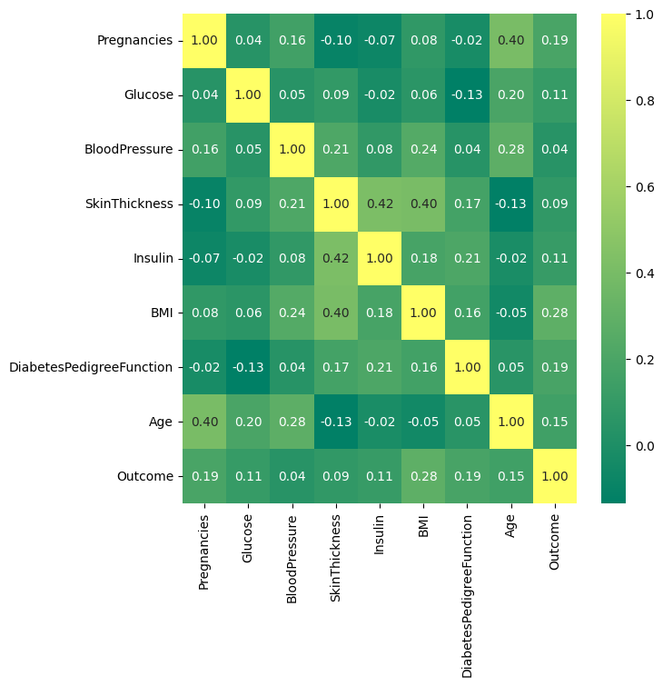

```python
plt.figure(figsize = (7, 7))
sns.heatmap(data.corr(), cmap = "summer", annot = True, fmt=".2f")
```

سوال 4: تعداد مشاهدات هر مقدار منحصر به فرد را بدست می‌آوریم. برای این کار از تابع ()value_counts استفاده می‌کنیم.

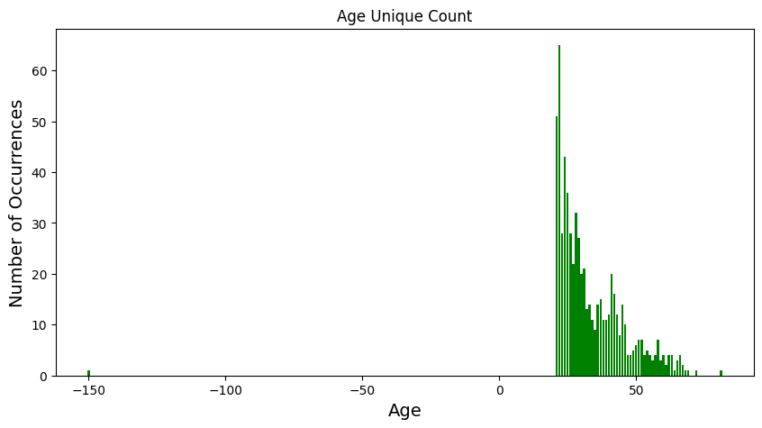

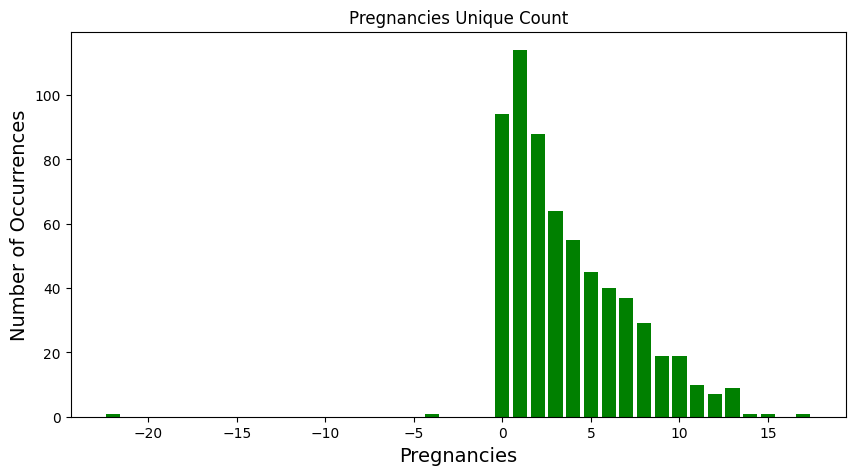

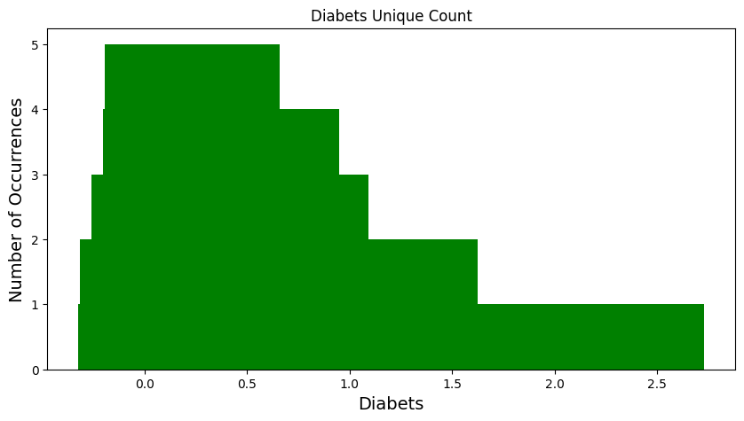

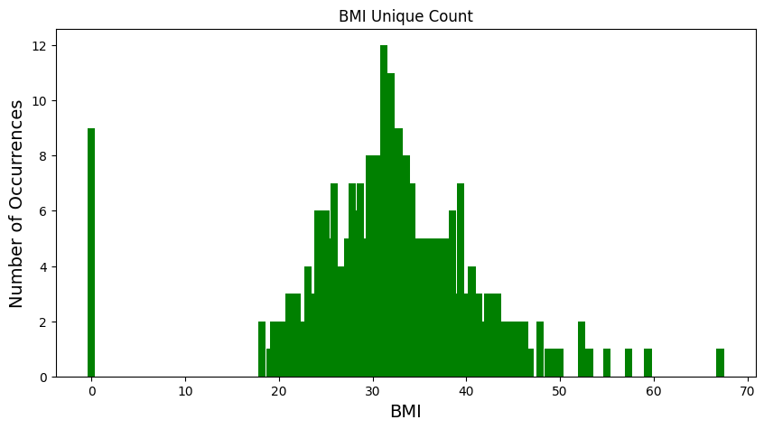

```python
Age_count = data['Age'].value_counts()
plt.figure(figsize = (10, 5))
plt.bar(Age_count.index, Age_count.values,color = 'green')
plt.title('Age Unique Count')
plt.ylabel('Number of Occurrences', fontsize = 14)
plt.xlabel('Age', fontsize = 14)
plt.show()

Pregnancies_count = data['Pregnancies'].value_counts()
plt.figure(figsize = (10, 5))
plt.bar(Pregnancies_count.index, Pregnancies_count.values,color = 'green')
plt.title('Pregnancies Unique Count')
plt.ylabel('Number of Occurrences', fontsize = 14)
plt.xlabel('Pregnancies', fontsize = 14)
plt.show()

Diabets_count = data['DiabetesPedigreeFunction'].value_counts()
plt.figure(figsize = (10, 5))
plt.bar(Diabets_count.index,Diabets_count.values,color = 'green')
plt.title('Diabets Unique Count')
plt.ylabel('Number of Occurrences', fontsize = 14)
plt.xlabel('Diabets', fontsize = 14)
plt.show()

BMI_count = data['BMI'].value_counts()
plt.figure(figsize = (10, 5))
plt.bar(BMI_count.index, BMI_count.values,color = 'green')
plt.title('BMI Unique Count')
plt.ylabel('Number of Occurrences', fontsize = 14)
plt.xlabel('BMI', fontsize = 14)
plt.show()
```

سوال 5:

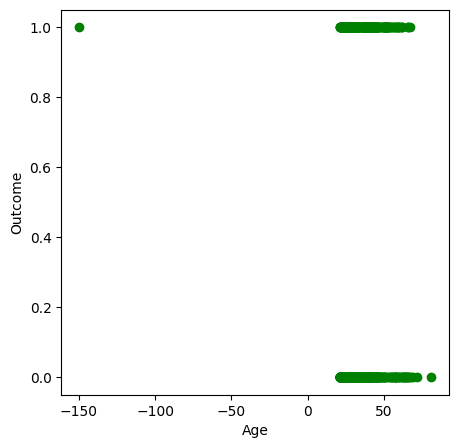

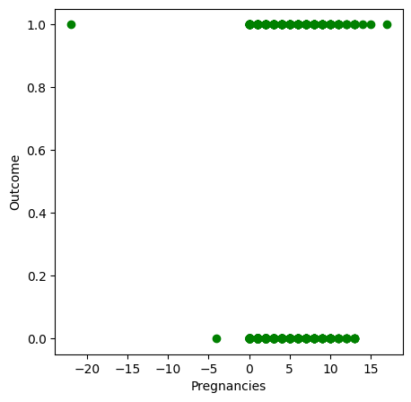

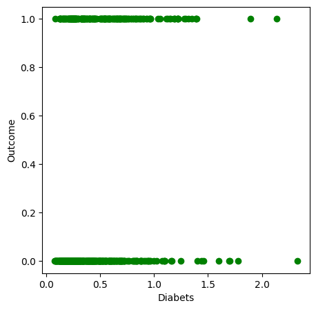

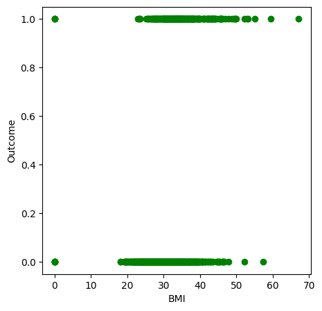

```python
plt.figure(figsize = (5, 5))
plt.scatter(data['Age'],data['Outcome'],color = 'green')
plt.ylabel('Outcome', fontsize = 10)
plt.xlabel('Age', fontsize = 10)
plt.show()

plt.figure(figsize = (5, 5))
plt.scatter(data['Pregnancies'], data['Outcome'],color = 'green')
plt.ylabel('Outcome', fontsize = 10)
plt.xlabel('Pregnancies', fontsize = 10)
plt.show()

plt.figure(figsize = (5, 5))
plt.scatter(data['DiabetesPedigreeFunction'], data['Outcome'],color = 'green')
plt.ylabel('Outcome', fontsize = 10)
plt.xlabel('Diabets', fontsize = 10)
plt.show()

plt.figure(figsize = (5, 5))
plt.scatter(data['BMI'], data['Outcome'],color = 'green')
plt.ylabel('Outcome', fontsize = 10)
plt.xlabel('BMI', fontsize = 10)
plt.show()
```

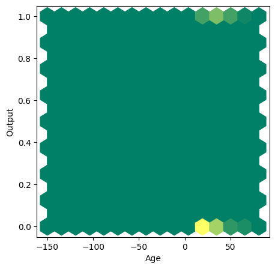

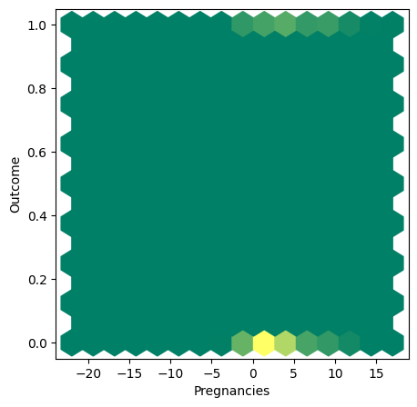

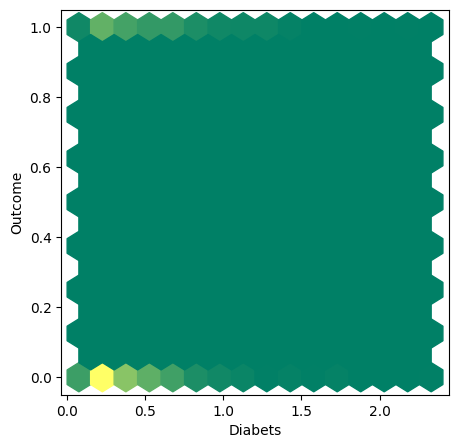

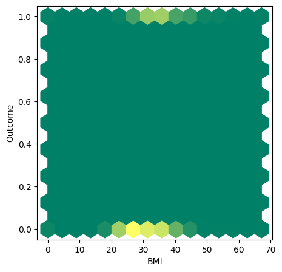

```python
plt.figure(figsize = (5, 5))
plt.hexbin(data['Age'],data['Outcome'],cmap = 'summer', gridsize = 15)
plt.ylabel('Output', fontsize = 10)
plt.xlabel('Age', fontsize = 10)
plt.show()

plt.figure(figsize = (5, 5))
plt.hexbin(data['Pregnancies'], data['Outcome'],cmap = 'summer', gridsize = 15)
plt.ylabel('Outcome', fontsize = 10)
plt.xlabel('Pregnancies', fontsize = 10)
plt.show()

plt.figure(figsize = (5, 5))
plt.hexbin(data['DiabetesPedigreeFunction'], data['Outcome'],cmap = 'summer', gridsize = 15)
plt.ylabel('Outcome', fontsize = 10)
plt.xlabel('Diabets', fontsize = 10)
plt.show()

plt.figure(figsize = (5, 5))
plt.hexbin(data['BMI'], data['Outcome'],cmap = 'summer', gridsize = 15)
plt.ylabel('Outcome', fontsize = 10)
plt.xlabel('BMI', fontsize = 10)
plt.show()
```

سوال 6: در این قسمت با توجه به اینکه تخمین داشتن دیابت را بررسی میکنیم، با توجه به مفهوم دیابت، میدانیم که به مقدار گلوکز و انسولین ربط دارد. در نتیجه این دو مورد را نیز لحاظ میکنیم و تعداد منحصر به فرد آنهارا به دست می‌آوریم.

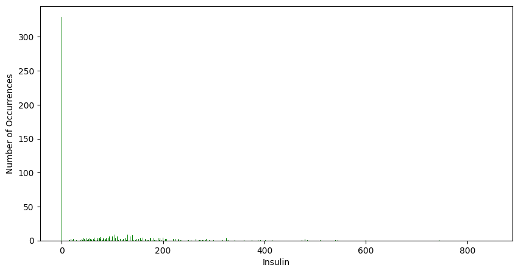

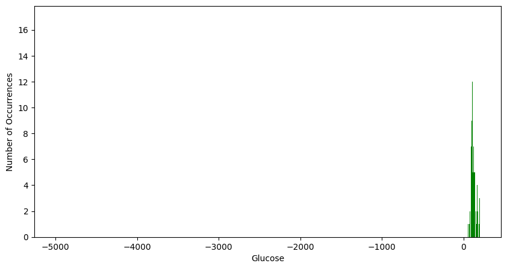

```python
Insulin_count = data['Insulin'].value_counts()
plt.figure(figsize = (10, 5))
plt.bar(Insulin_count.index, Insulin_count.values,color = 'green')
plt.ylabel('Number of Occurrences', fontsize = 10)
plt.xlabel('Insulin', fontsize = 10)
plt.show()

Glucose_count = data['Glucose'].value_counts()
plt.figure(figsize = (10, 5))
plt.bar(Glucose_count.index, Glucose_count.values,color = 'green')
plt.ylabel('Number of Occurrences', fontsize = 10)
plt.xlabel('Glucose', fontsize = 10)
plt.show()
```

# پیش پردازش مجموعه داده

```python
#assign nan to negative values
for i in data.columns:
    col = data[i]
    if i != 'Outcome' and i != 'Pregnancies' and i != 'DiabetesPedigreeFunction':
        col[col <= 0] = np.nan
    if i == 'Pregnancies' or i == 'DiabetesPedigreeFunction':
        col[col < 0] = 0
    data[i] = col
data.describe()
```

|  | Pregnancies | Glucose | BloodPressure | SkinThickness | Insulin | BMI | DiabetesPedigreeFunction | Age | Outcome |
| --- | --- | --- | --- | --- | --- | --- | --- | --- | --- |
| count | 635.000000 | 649.000000 | 647.000000 | 438.000000 | 351.000000 | 675.000000 | 590.000000 | 654.000000 | 768.000000 |
| mean | 3.741732 | 122.000000 | 72.298300 | 29.043379 | 155.225071 | 32.511407 | 0.466676 | 33.437309 | 0.348958 |
| std | 3.359070 | 30.798028 | 12.427961 | 10.600092 | 119.458674 | 6.909103 | 0.322408 | 11.836619 | 0.476951 |
| min | 0.000000 | 44.000000 | 24.000000 | 7.000000 | 14.000000 | 18.200000 | 0.078000 | 21.000000 | 0.000000 |
| 25% | 1.000000 | 99.000000 | 64.000000 | 21.250000 | 76.000000 | 27.500000 | 0.243250 | 24.000000 | 0.000000 |
| 50% | 3.000000 | 117.000000 | 72.000000 | 29.000000 | 126.000000 | 32.400000 | 0.368000 | 29.000000 | 0.000000 |
| 75% | 6.000000 | 141.000000 | 80.000000 | 36.000000 | 190.000000 | 36.650000 | 0.611500 | 41.000000 | 1.000000 |
| max | 17.000000 | 199.000000 | 122.000000 | 99.000000 | 846.000000 | 67.100000 | 2.329000 | 81.000000 | 1.000000 |

سوال 1:  
انواع روش ها برای حل Missing Values را بررسی میکنیم.

- حذف کل ستون: در این روش ستون هایی که در آن Missing Value داریم را حذف میکنیم. این روش میتواند باعث از دست رفتن مقدار زیادی داده شود و مناسب نیست. این روش برای زمانی مناسب است که مقدار Missing Value در ستون بسیار زیاد باشد.
- حذف کل ردیف: در این روش ردیف هایی که در آن Missing Value داریم را حذف میکنیم. این روش میتواند باعث از دست رفتن مقدار زیادی داده شود و مناسب نیست. این روش برای زمانی مناسب است که مقدار Missing Value در ردیف بسیار زیاد باشد.
- تعویض با مقدار میانگین: در این روش مقدار داده های گمشده را با مقدار میانگین جایگزین میکنیم. مزیت این روش آن است که مقدار میانگین را تغییر نمیدهد ولی بدی دارد و آن این است که مقدار انحراف معیار و واریانس را تغییر میدهد و اگر این مقادیر برایمان مهم باشد، به مشکل میخوریم.
- تعویض با مقدار مد: استفاده از این روش برای داده های غیر عددی مناسب است. زیرا در اینجور داده های نمیتوان میانگین یا میانه را محاسبه کرد و محاسبه مد بهترین روش برای پر کردن داده های گمشده میباشد.
- تعویض با مقدار میانه: اگر در داده هایمان مقادیر پرت داشته باشیم، استفاده از این روش بهترین گزینه میباشد زیرا میانه مقداریست که در میان داده های پرت قرار دارد و از آنها تاثیر نمیگیرد ولی داده های پرت روی میانگین تاثیر دارند.

سوال 2:  
با استفاده از isnull().sum() میتوانیم تعداد Missing Value های هر ستون را مشاهده کنیم. همانطور که مشخص است، ستون انسولین و ضخامت پوست بیشترین نسبت داده گم شده را دارند. پس این ستون ها را حذف میکنیم و باقی ستون ها را با مقدار میانه پر میکنیم.

```python
data.isnull().sum() / len(data)
```

```
Pregnancies                 0.173177
Glucose                     0.154948
BloodPressure               0.157552
SkinThickness               0.429688
Insulin                     0.542969
BMI                         0.121094
DiabetesPedigreeFunction    0.231771
Age                         0.148438
Outcome                     0.000000
dtype: float64
```

```python
data.drop(columns=['Insulin'], inplace=True)
data.drop(columns=['SkinThickness'], inplace=True)
data['DiabetesPedigreeFunction'].fillna(data['DiabetesPedigreeFunction'].median(), inplace = True)
data['Pregnancies'].fillna(data['Pregnancies'].median(), inplace = True)
data['Glucose'].fillna(data['Glucose'].median(), inplace = True)
data['Age'].fillna(data['Age'].median(), inplace = True)
data['BloodPressure'].fillna(data['BloodPressure'].median(), inplace = True)
data['BMI'].fillna(data['BMI'].median(), inplace = True)
data.isnull().sum()
```

```
Pregnancies                 0
Glucose                     0
BloodPressure               0
BMI                         0
DiabetesPedigreeFunction    0
Age                         0
Outcome                     0
dtype: int64
```

سوال 3:

- Nomalization: نرمال سازی ویژگی های عددی را در محدوده 0 و 1 قرار میدهد. در کل هدف این است که دامنه همه ستون ها یکسان شود. در اینجا نیز بهتر است داده ها را نرمالایز کنیم زیرا داده های پرت که همان عددهای منفی بودند را حذف کردیم، و اگر داده پرت کم داشته باشیم، این روش بهترین گزینه میباشد.
- Standardization: این روش یعنی داده ها بر اساس صفت هایشان به گونه ای توزیع شوند که میانگین صفر و انحراف معیار یک میشود و یک توزیع گوسی را در داده های ما فرض میکند.

برای نرمالایز کردن داده ها، کافیست از تابع مین و ماکس بهره ببریم که در زیر استفاده شده است. همچنین برای استاندارد سازی از mean() و std() استفاده شده است.

```python
data2 = data[data.columns.difference(['Outcome'])]
data2 = (data2 - data2.mean()) / data2.std()
data = pd.concat([data2, data['Outcome']], axis=1)

data = (data - data.min()) / (data.max() - data.min())

data.head()
```

|  | Age | BMI | BloodPressure | DiabetesPedigreeFunction | Glucose | Pregnancies | Outcome |
| --- | --- | --- | --- | --- | --- | --- | --- |
| 0 | 0.483333 | 0.314928 | 0.489796 | 0.243892 | 0.670968 | 0.352941 | 1.0 |
| 1 | 0.166667 | 0.171779 | 0.428571 | 0.121279 | 0.264516 | 0.058824 | 0.0 |
| 2 | 0.183333 | 0.104294 | 0.408163 | 0.263883 | 0.896774 | 0.176471 | 1.0 |
| 3 | 0.000000 | 0.202454 | 0.428571 | 0.039538 | 0.290323 | 0.058824 | 0.0 |
| 4 | 0.200000 | 0.290389 | 0.163265 | 0.128832 | 0.600000 | 0.176471 | 1.0 |

سوال 4:  
برای ویژگی های دسته ای روش های زیر را میتوان به کار برد:

- Dummy Encoding: در این روش از 0 و 1 استفاده میشود. این مدل راهی برای ترکیب متغیر های اسمی در تجزیه و تحلیل رگرسیون است. رگرسیون ها معمولا به دلیل استفاده از متغیر های پیوسته برای پیشبینی یک مقدار نتیجه پیشبینی میشوند.
- One Hot Encoding: در این روش هر دسته به صورت یک ستون جداگانه در نظر گرفته میشود و اگر دسته ای در یک ستون وجود داشته باشد، مقدار آن ستون 1 میشود و در غیر این صورت 0 میشود. این روش بهترین روش برای داده های دسته ای میباشد که ترتیب خاصی هم ندارند.
- Binary Encoding: در این روش ابتدا ویژگی های دسته ای به عددی تبدیل میشوند سپس این اعداد به اعداد باینری تبدیل میگردند. پس از آن، آن عدد های باینری به ستون های مختلف تقسیم میشوند.
- Target Encoding: در این روش هر دسته به یک مقدار تبدیل میشود که معمولا میانگین مقدار هدف در آن دسته است. این روش بهترین روش برای داده های دسته ای میباشد که ترتیب خاصی دارند.
- Ordinal Encoding: در این روش هر دسته به یک عدد تبدیل میشود که معمولا ترتیب دسته ها را نشان میدهد. این روش بهترین روش برای داده های دسته ای میباشد که ترتیب خاصی دارند.

خیر . راه خوبی نیست. بهترین کار این است که درمورد داده های دسته ای خودمان بررسی کنیم و ببینیم ویژگی های هر دسته به چه صورت است و برای همه یک روش را به کار نبریم. بهترین روش، Ordinal Encoding است. زیرا در این صورت مقدار دهی هر داده دسته ای دست خودمان است و مدیریت کردن آن ها راحت تر میشود.

سوال 5:  
در قسمت های قبل، ستون Insulinو Thickness skin را حذف کردیم زیرا مقدار داده NaN بسیار زیادی داشتند. ولی الان نمیتوانیم ستونی را حذف کنیم زیرا ممکن است ویژگی موردنظر با Outcome وابستگی زیادی نداشته باشد ولی ترکیب آن با ستون های دیگر باعث شود تاثیر قابل توجهی روی مقدار نتیجه ایجاد شود.

سوال 6:  
تقسیم داده ها یک فرآیند مهم محسوب میشود و از طرفی بستگی به این دارد که داده های ما چگونه چیده شده اند و چه ترتیبی دارند. از train_test_split استفاده میکنیم و داده ها را به صورت تصادفی تقسیم میکنیم. این روش بهترین روش برای تقسیم داده ها است. از طرف دیگر باید از یه درصدی برای آموزش و تست استفاده کنیم. اگر از کل داده ها برای آموزش یا برای تست استفاده کنیم، ممکن است اندازه گیری های ما دقیق نباشد. حدود 20 تا 30 درصد از داده ها را برای تست استفاده میکنیم. این درصد بستگی به تعداد داده ها و ویژگی ها دارد.

train_test_split برای تقسیم مجموعه داده های ما به دو بخش train و test میباشند. ابتدا باید داده های خود را به دو بخش ویژگی های X و label y تقسیم کنیم. دیتافریم به چهار بخش X_train و X_test و y_train و y_test تقسیم میشود. برای آموزش و تست مدل، از X_train و y_train استفاده میکنیم. برای اندازه گیری مدل، از X_test و y_test استفاده میکنیم.

روش دیگر cross validation است. در این روش داده ها به دسته های k تایی تقسیم میشوند و هربار یک دسته را بیرون نگه میداریم و روی دسته های دیگر تمرکز میکنیم. این روش داده هارا کاهش میدهد و اطمینان حاصل میکند که مدل ما به اندازه کافی قوی هست.

```python
x = data[data.columns.difference(['Outcome'])]
y = data['Outcome']
x_train, x_test, y_train, y_test = train_test_split(x, y, test_size=0.3, random_state=1)
```

سوال 7: دسته سوم validation نام دارد و با وجود دسته سوم، تقسیم بندی داده ها نقریبا به صورت 10 10 80 میباشد. 80 متعلق به داده آموزشی است و 10 و 10 متعلق به داده آزمایشی و validation میباشند. کابرد validation این است که بهترین مدل برای برای داده هایی که تاحالا آنهارا ندیدیم را انتخاب کند. به عبارت دیگر، validation data اولین آزمایش را در برابر داده های دیده نشده ارائه میکند و این امکان را به افراد میدهد که مدل خود را برای داده های دیده نشده ارزیابی کنند.

# آموزش، ارزیابی و تنظیم

```python
#k nearest neighbor
knearest = KNeighborsClassifier(n_neighbors=11)
knearest.fit(x_train, y_train)
prediction_knearest_test = knearest.predict(x_test)
print("Accuracy of K Nearest Neighbor for test: ",metrics.accuracy_score(y_test, prediction_knearest_test))

#decision tree
decision_tree = DecisionTreeClassifier(criterion= "entropy", max_depth=8, min_samples_leaf=2, min_samples_split = 7, random_state=42, splitter = 'best')
decision_tree.fit(x_train, y_train)
prediction_tree_test = decision_tree.predict(x_test)
print("Accuracy of Decision tree for test:",metrics.accuracy_score(y_test, prediction_tree_test))

#logistic regression
logistic_regression = LogisticRegression()
logistic_regression.fit(x_train, y_train)
prediction_logistic_test = logistic_regression.predict(x_test)
print("Accuracy of logistic regression for test: ",metrics.accuracy_score(y_test, prediction_logistic_test))
```

```
Accuracy of K Nearest Neighbor for test:  0.7792207792207793
Accuracy of Decision tree for test: 0.8008658008658008
Accuracy of logistic regression for test:  0.7748917748917749
```

سوال 1:  
ماتریس درهم ریختگی یک جدول است که برای ارزیابی محل خطای مدل ما استفاده میشود. ردیف ها نشاندهنده نتیجه واقعی و ستون ها نشاندهنده پیشبینی ای هستند که مدل ما آن را انجام داده است. ماتریس درهم ریختگی 4 بخش دارد.

حال به ازای هر سه بخش ماتریس درهم ریختگی را بررسی میکنیم.

حالا به بررسی دقت هر سه مدل با استفاده از ماتریس درهم ریختگی میپردازیم.

$$ Accuracy = \frac{TP+TN}{TP+TN+FP+FN} $$$$ Decision tree = \frac{125+60}{125+60+25+21} = 0.800865801 $$$$ KNN = \frac{131+49}{131+49+36+15} = 0.779220779 $$$$ Logistic regression = \frac{134+45}{134+45+40+12} = 0.774891775 $$

مقدار این مقادیر با مقادیری که در قسمت قبل به دست آوردیم برابر است پس ماتریس درهم ریختگی درست کار میکند.

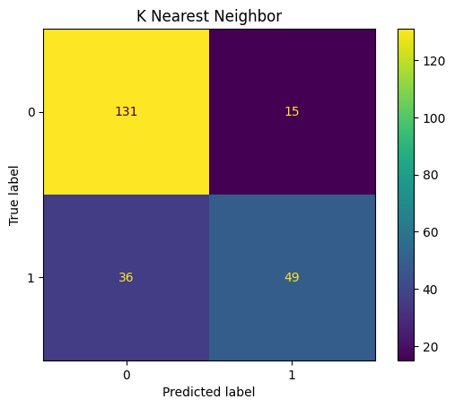

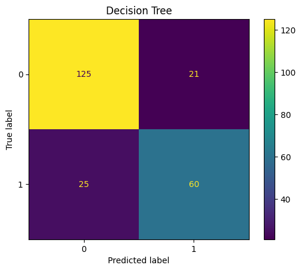

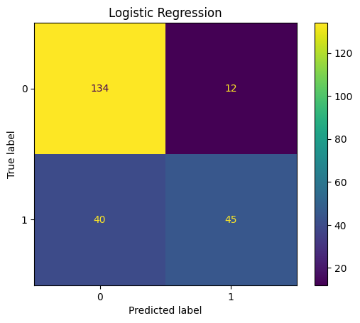

```python
#matrix confusion for knearest neighbor
matrix_knearest = metrics.confusion_matrix(y_test, prediction_knearest_test)
matrix_display = metrics.ConfusionMatrixDisplay(matrix_knearest).plot()
plt.title('K Nearest Neighbor')
plt.show()

#matrix confusion for decision tree
matrix_decision_tree = metrics.confusion_matrix(y_test, prediction_tree_test)
matrix_display = metrics.ConfusionMatrixDisplay(matrix_decision_tree).plot()
plt.title('Decision Tree')
plt.show()

#matrix confusion for logistic regression
matrix_logistic_regression = metrics.confusion_matrix(y_test, prediction_logistic_test)
matrix_display = metrics.ConfusionMatrixDisplay(matrix_logistic_regression).plot()
plt.title('Logistic Regression')
plt.show()
```

سوال 2: gridsearchcv بهترین مقادیر برای هر پارامتر را انتخاب میکند و بهترین مدل را با این پارامترها میسازد. در ابتدا ما پارامتر هایی که موردنیازمان هست به همراه مقادیر مختلف آنها به gridsearchcv میدهیم و سپس این تابع بهترین مقادیر را برای هر پارامتر انتخاب میکند و بهترین مدل را با این پارامترها میسازد. ولی گاهی ممکن است با این پارامتر ها نتوانیم دقت بهتری بدست بیاوریم دلیلش آن است که این تابع فقط روی داده آموزشی fit میشود و خودش بخشی از آن را به عنوان داده آزمایشی در نظر میگیرد و باتوجه به آن بهترین پارامتر ها را انتخاب میکند. به همین دلیل امکان دارد نتواند بهترین عملکرد را داشته باشد.

```python
#grid search
grid_parameters = { 'min_samples_leaf': range(3,10), 'max_depth': range(3,10), 'min_samples_split': range(2,10),'criterion': ['entropy'], 'splitter': ['best']}
grid_search = GridSearchCV(decision_tree, grid_parameters, cv=3)
grid_search.fit(x_train, y_train)
print(grid_search.best_params_)
```

```
{'criterion': 'entropy', 'max_depth': 4, 'min_samples_leaf': 3, 'min_samples_split': 2, 'splitter': 'best'}
```

سوال 3:

- underfitting: این اتفاق زمانی رخ میدهد که مدل ما روی داده آموزشی و آزمایشی عملکرد خوبی ندارد. underfitting دقت یادگیری مدل ما را از بین میبرد و معمولا زمانی رخ میدهد که داده کمتری برای ساخت یک مدل داشته باشیم. زیرا اگر داده آموزشی کم باشد، نمیتواند همه حالت های مختلف را پوشش دهد در نتیجه در هنگام مواجه با داده جدید، عملکرد خوبی ندارد. از عواملی که باعث بروز underfitting میشوند میتوان به بایاس بالا و واریانس کم، کم بودن سایز داده آموزشی و داده های نویز دار اشاره کرد. از راه های بهبود underfitting نیز میتوان به پیچیده کردن مدل، حذف داده های نویز دار، افزایش سایز داده آموزشی و افزایش ویژگی ها اشاره کرد.
- overfitting: هنگامی اتفاق میفتد که مدل ما روی داده آموزشی خوب عمل میکند ولی روی داده آزمایشی نتیجه مطلوبی ندارد. وقتی مدل ما تعداد زیادی داده برای آموزش میگیرد، داده های غلط و نویز را نیز در دیتاست ما وارد میکند. این باعث میشود مدل ما روی داده آموزشی بسیار خوب عمل کند ولی عملکرد خوبی روی داده آزمایشی نداشته باشد پس واریانس زیاد میگردد. از دلایل overfitting میتوان به واریانس بالا و بایاس کم، پیچیدگی مدل و سایز داده آموزشی اشاره کرد. از راه های بهبود آن نیز میتوان به کم کردن پیچیدگی داده آموزشی و افزایش داده آموزشی اشاره کرد.

برای اینکه ببینیم مدل ما دچار overfitting یا underfitting شده است یا خیر، میتوانیم مقدار دقت داده آموزشی را بدست بیاوریم و با دقت داده آزمایشی مقایسه کنیم. اگر اختلاف آنها کم باشد و هردو از دقت قابل قبولی برخوردار باشند، پس میفهمیم مدل ما درست کار میکند که در پایین این کار انجام گرفته است و با توجه به دقت ها، میتوان از درست بودن مدلمان مطمئن شویم.

```python
decision_tree = DecisionTreeClassifier(criterion= "entropy", max_depth=8, min_samples_leaf=2, min_samples_split = 7, random_state=42, splitter = 'best')
decision_tree.fit(x_train, y_train)
prediction_tree_train = decision_tree.predict(x_train)
print("Accuracy of Decision tree for train:",metrics.accuracy_score(y_train, prediction_tree_train))
print("Accuracy of Decision tree for test:",metrics.accuracy_score(y_test, prediction_tree_test))
print("***************************************")

knearest = KNeighborsClassifier(n_neighbors=11)
knearest.fit(x_train, y_train)
prediction_knearest_train = knearest.predict(x_train)
print("Accuracy of K Nearest Neighbor for train: ",metrics.accuracy_score(y_train, prediction_knearest_train))
print("Accuracy of K Nearest Neighbor for test: ",metrics.accuracy_score(y_test, prediction_knearest_test))
print("***************************************")

logistic_regression = LogisticRegression()
logistic_regression.fit(x_train, y_train)
prediction_logistic_train = logistic_regression.predict(x_train)
print("Accuracy of logistic regression for train: ",metrics.accuracy_score(y_train, prediction_logistic_train))
print("Accuracy of logistic regression for test: ",metrics.accuracy_score(y_test, prediction_logistic_test))
print("***************************************")
```

```
Accuracy of Decision tree for train: 0.8547486033519553
Accuracy of Decision tree for test: 0.8008658008658008
Accuracy of K Nearest Neighbor for train:  0.7821229050279329
Accuracy of K Nearest Neighbor for test:  0.7792207792207793
Accuracy of logistic regression for train:  0.7579143389199255
Accuracy of logistic regression for test:  0.7748917748917749
```

سوال 4: در پیش پردازه دو ستون از داده اصلی را که بیشترین درصد NaN را داشت، حذف کردیم. این اتفاق تاثیر زیادی روی دقت مدل ما داشت. اگر این دو ستون را حذف نکنیم، مدل ما دچار overfitting میشود و دقت آن پایین می آید. زیرا داده های نویز را نیز سعی میکند هندل کند و این دقت ما را کاهش میدهد. حذف ستون هایی که بیشترین درصد NaN را دارند، میتواند مدل ما را از overfitting نجات دهد.

# روش های یادگیری جمعی

```python
def rand_forest():
    random_forest = RandomForestClassifier(random_state = 42)
    random_forest.fit(x_train, y_train)
    predict_forest = random_forest.predict(x_test)
    return metrics.accuracy_score(y_test, predict_forest)

random_forest = rand_forest()
print("Accuracy of random forest is: ", random_forest)
```

```
Accuracy of random forest is:  0.7489177489177489
```

سوال 1:  
برای این قسمت سه پارامتر را بررسی میکنیم.

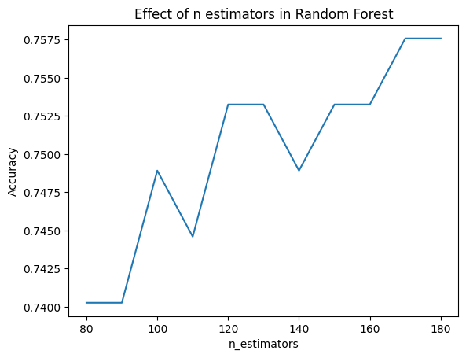

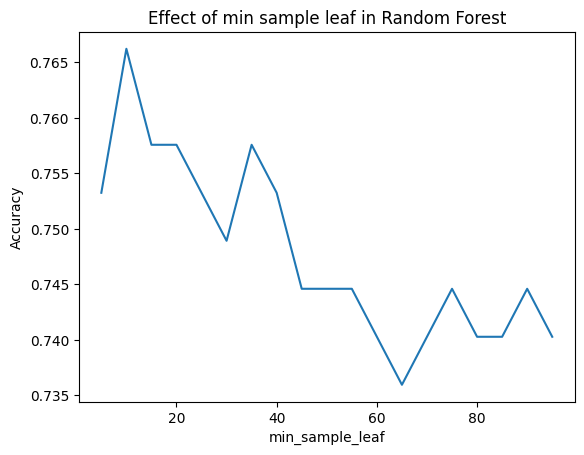

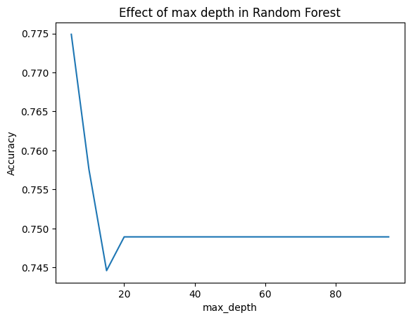

```python
def plot_nestimator():
    nestimator = []
    nestimator_index = [80,90,100,110,120,130,140,150,160,170,180]
    for i in nestimator_index:
        random_forest_nestimator = RandomForestClassifier(n_estimators = i, random_state = 42)
        random_forest_nestimator.fit(x_train, y_train)
        predict_forest_nestimator = random_forest_nestimator.predict(x_test)
        accuracy = metrics.accuracy_score(y_test, predict_forest_nestimator)
        nestimator.append(accuracy)
    plt.plot(nestimator_index, nestimator)
    plt.title('Effect of n estimators in Random Forest')
    plt.xlabel('n_estimators')
    plt.ylabel('Accuracy')
    plt.show()

def plot_minsampleleaf():
    minsampleleaf = []
    minsampleleaf_index = [5,10,15,20,25,30,35,40,45,50,55,60,65,70,75,80,85,90,95]
    for i in minsampleleaf_index:
        random_forest_minsampleleaf = RandomForestClassifier(min_samples_leaf = i, random_state = 42)
        random_forest_minsampleleaf.fit(x_train, y_train)
        predict_forest_minsampleleaf = random_forest_minsampleleaf.predict(x_test)
        accuracy = metrics.accuracy_score(y_test, predict_forest_minsampleleaf)
        minsampleleaf.append(accuracy)
    plt.plot(minsampleleaf_index, minsampleleaf)
    plt.title('Effect of min sample leaf in Random Forest')
    plt.xlabel('min_sample_leaf')
    plt.ylabel('Accuracy')
    plt.show()


def plot_maxdepth():
    maxdepth = []
    maxdepth_index = [5,10,15,20,25,30,35,40,45,50,55,60,65,70,75,80,85,90,95]
    for i in maxdepth_index:
        random_forest_maxdepth = RandomForestClassifier(max_depth = i, random_state = 42)
        random_forest_maxdepth.fit(x_train, y_train)
        predict_forest_maxdepth = random_forest_maxdepth.predict(x_test)
        accuracy = metrics.accuracy_score(y_test, predict_forest_maxdepth)
        maxdepth.append(accuracy)
    plt.plot(maxdepth_index, maxdepth)
    plt.title('Effect of max depth in Random Forest')
    plt.xlabel('max_depth')
    plt.ylabel('Accuracy')
    plt.show()

plot_nestimator()
plot_minsampleleaf()
plot_maxdepth()
```

سوال 2:

- Bias: بایاس یک خطای سیستماتیک است که در مدل یادگیری ماشین به دلیل فرضیات نادرست در ماشین لرنینگ رخ میدهد. به عبارت دیگر بایاس درواقع میزان خطای داده های آموزشی میباشد. زمانی که میزان خطا بسیار زیاد باشد، به آن high bias و زمانی که میزان خطا بسیار کم باشد، به آن low bias میگویند.
- Variance: این ویژگی تفاوت میان مقدار پیش بینی شده توسط مدل و مقدار واقعی را نشان میدهد. اگر این مقدار خیلی کم باشد واریانس کم است و مدل ما overfitting را نشان میدهد و اگر این مقدار خیلی زیاد باشد واریانس زیاد است و مدل ما underfitting را نشان میدهد. ما معمولا برای داده های خود دنبال کم کردن واریانس هستیم زیرا واریانس زیاد نشاندهنده این است که ما به درستی نتوانستیم مدل را آموزش دهیم.

همانطور که میدانیم، در random forest تعدادی decision tree با ویژگی های متفاوت ساخته میشود و در نهایت بین نتایچ درخت ها نوعی رای گیری انجام میشود. در این حالت، چون همه ویژگی ها در یک درخت در نظر گرفته نمیشود، ارور بیشتری رخ میدهد در نتیجه مقدار بایاس از decision tree بیشتر میگردد. از طرفی میدانیم تقریبا بایاس و واریانس با یکدیگر نسبت عکس دارند و زیاد شدن یکی منجر به کم شدن دیگری میشود. با این اوصاف، واریانس در random forest کمتر میگردد.

```python
from mlxtend.evaluate import bias_variance_decomp

#bias and variance for decision tree
_,bias_decision_tree, var_decision_tree = bias_variance_decomp(decision_tree, x_train.values, y_train.values, x_test.values, y_test.values)
print("Bias for decision tree: ", bias_decision_tree)
print("Variance for decision tree: ", var_decision_tree)
print("***************************************")

random_forest = RandomForestClassifier(random_state = 42)
random_forest.fit(x_train, y_train)
_,bias_random_forest, var_random_forest = bias_variance_decomp(random_forest, x_train.values, y_train.values, x_test.values, y_test.values)
print("Bias for random forest: ", bias_random_forest)
print("Variance for random forest: ", var_random_forest)
print("***************************************")
```

```
Bias for decision tree:  0.22510822510822512
Variance for decision tree:  0.1951298701298701
Bias for random forest:  0.24675324675324675
Variance for random forest:  0.09404761904761906
```